# **Palau Demographics**

# Introduction

# About Palau

Palau is a group of islands in the Pacific Ocean, known for its clear waters and diverse marine life. The islands, including the well-known Rock Islands and Jellyfish Lake, attract visitors and researchers alike, with a focus on conservation and mindful tourism to protect its ecosystems. The Palauans maintain a strong cultural heritage and traditions, with a society that values women in leadership through a more matrilineal system.

Palau has a history marked by various international influences, having experienced Spanish, German, and Japanese rule in different periods. After World War II, Palau was part of the Trust Territory of the Pacific Islands under the United States. In 1994, Palau gained independence and established a compact of free association with the United States, receiving military defense and financial assistance, while also maintaining a degree of autonomy. The nation, as a relatively young republic, blends its historical experiences with its current governance, creating a political narrative that is both rich and complex.

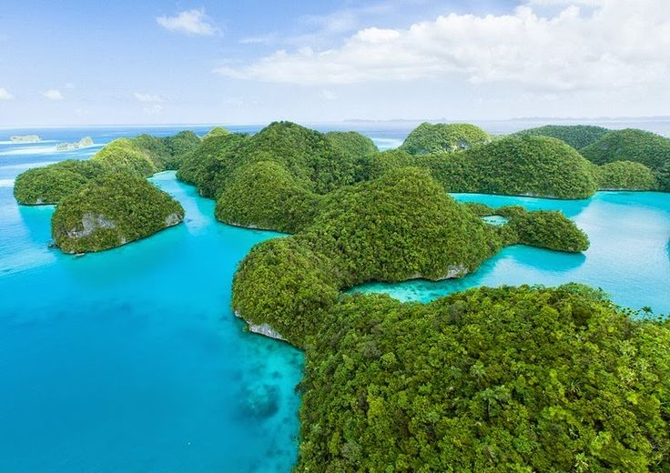

# Population Structure and Growth

# Fertility and Reproduction

# Bonus Content

## Demographics of the Shire in the Third Age